# Chapter 5

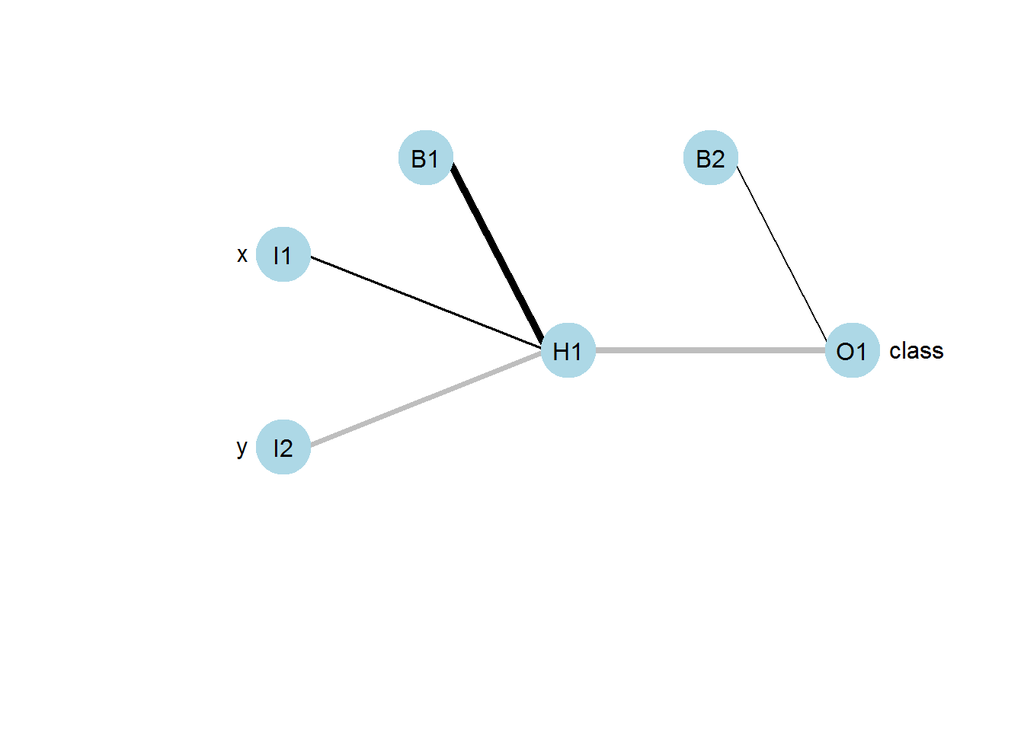

```r
plot(model)
```

nnet with 10 neurons

```r
model=nnet(class~.,data=mydata[train,],size=10)
predclass=predict(model,newdata=mydata[-train,],type="class")
confmatrix(mydata$class[-train],predclass)
```

```
## $matrix
##    predy
## y     A   B
##   A 126  25
##   B   6 143
##
## $accuracy
## [1] 0.8966667
##
## $error
## [1] 0.1033333
```

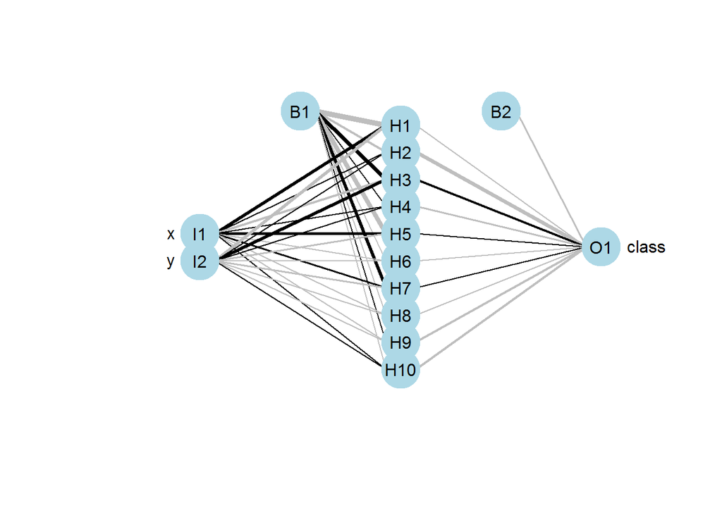

```r
plot(model)
```

pihat and roc curve

```r
pihat=predict(model,newdata=mydata[-train,])
table(pihat>=0.5,predclass)   #B = 1
```

```
##        predclass
##           A   B
##   FALSE 132   0
##   TRUE    0 168
```

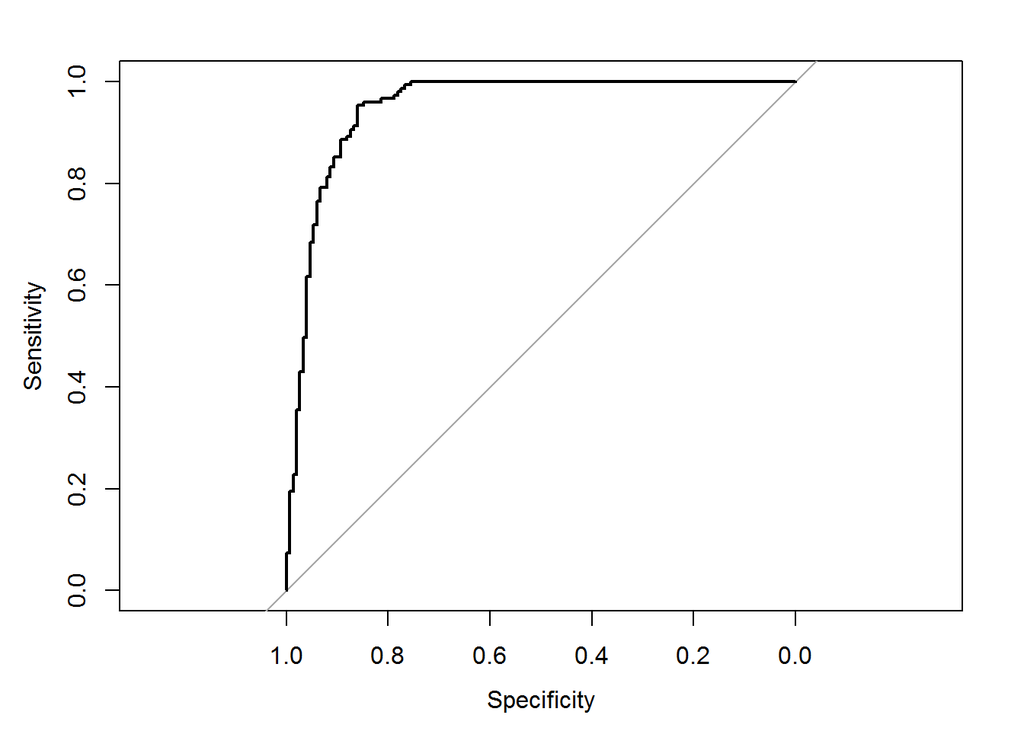

```
##
## Call:
## roc.default(response = mydata$class[-train], predictor = pihat)
##
## Data: pihat in 151 controls (mydata$class[-train] A) < 149 cases (mydata$class[-train] B).
## Area under the curve: 0.9502
```

```r
library(pROC)
plot(roc(response=mydata$class[-train],predictor=pihat))
```

How big can we make the model

```r
for(i in 1:20){
  tempmodel=nnet(class~.,data=mydata[train,],size=i)
  print(paste(i,"is ok"))
}
```

```
## [1] "1 is ok"
## [1] "2 is ok"
## [1] "3 is ok"
## [1] "4 is ok"
## [1] "5 is ok"
## [1] "6 is ok"
## [1] "7 is ok"
## [1] "8 is ok"
## [1] "9 is ok"
## [1] "10 is ok"
## [1] "11 is ok"
## [1] "12 is ok"
## [1] "13 is ok"
## [1] "14 is ok"
## [1] "15 is ok"
## [1] "16 is ok"
## [1] "17 is ok"
## [1] "18 is ok"
## [1] "19 is ok"
## [1] "20 is ok"
```

Choosing size using k-fold CV

createfolds function and find the accuracy over multiple iterations

```r
createfolds=function(n,K){
  reps=ceiling(n/K)
  folds=sample(rep(1:K,reps))
  return(folds[1:n])
}

#Folds for mydata
set.seed(5364)
folds=createfolds(nrow(mydata),10)

#k-fold CV for Neural Net
accmatrix=matrix(nrow=19,ncol=10)


for(netsize in 1:19){
  for(k in 1:10){
    temptest=mydata[folds==k,]
    temptrain=mydata[folds!=k,]

    tempnnet=nnet(class~.,data=temptrain,size=netsize)
    accmatrix[netsize,k]=confmatrix(temptest$class,
                                    predict(tempnnet,newdata=temptest,type="class"))$accuracy
  }}
accmatrix
```

```
##       [,1] [,2] [,3] [,4] [,5] [,6] [,7] [,8] [,9] [,10]
##  [1,] 0.54 0.71 0.64 0.62 0.61 0.49 0.74 0.67 0.55  0.65
##  [2,] 0.69 0.82 0.80 0.77 0.74 0.73 0.82 0.79 0.73  0.65
##  [3,] 0.86 0.82 0.79 0.77 0.85 0.85 0.81 0.92 0.81  0.73
##  [4,] 0.86 0.89 0.92 0.77 0.85 0.86 0.95 0.92 0.81  0.78
##  [5,] 0.86 0.89 0.92 0.95 0.84 0.86 0.95 0.91 0.82  0.85
##  [6,] 0.86 0.88 0.92 0.94 0.83 0.85 0.96 0.79 0.82  0.85
##  [7,] 0.87 0.89 0.92 0.94 0.85 0.83 0.96 0.91 0.84  0.86
##  [8,] 0.85 0.89 0.91 0.94 0.83 0.86 0.95 0.92 0.82  0.86
##  [9,] 0.86 0.87 0.87 0.93 0.83 0.86 0.94 0.92 0.81  0.86
## [10,] 0.86 0.86 0.90 0.94 0.84 0.85 0.96 0.92 0.82  0.86
## [11,] 0.85 0.87 0.91 0.93 0.84 0.83 0.93 0.91 0.79  0.84
## [12,] 0.87 0.87 0.94 0.93 0.84 0.84 0.92 0.91 0.80  0.85
## [13,] 0.89 0.90 0.92 0.94 0.83 0.84 0.93 0.93 0.82  0.85
## [14,] 0.86 0.87 0.89 0.94 0.84 0.86 0.96 0.92 0.81  0.86
## [15,] 0.85 0.85 0.93 0.93 0.83 0.85 0.93 0.91 0.79  0.83
## [16,] 0.87 0.91 0.90 0.94 0.82 0.80 0.94 0.92 0.80  0.84
## [17,] 0.86 0.87 0.90 0.95 0.83 0.83 0.94 0.91 0.81  0.86
## [18,] 0.85 0.88 0.93 0.95 0.83 0.85 0.92 0.90 0.79  0.86
## [19,] 0.87 0.87 0.92 0.93 0.84 0.83 0.92 0.92 0.84  0.86
```

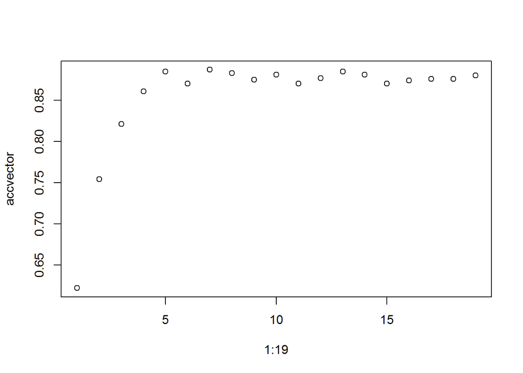

```r
accvector=apply(accmatrix,1,mean)
plot(1:19,accvector)
```

```r
which.max(accvector)
```

```
## [1] 7
```

```r
model=nnet(class~.,data=mydata[train,],size=5)
predclass=predict(model,newdata=mydata[-train,],type="class")
confmatrix(mydata$class[-train],predclass)
```

```
## $matrix
##    predy
## y     A   B
##   A 127  24
##   B   4 145
##
## $accuracy
## [1] 0.9066667
##
## $error
## [1] 0.09333333
```

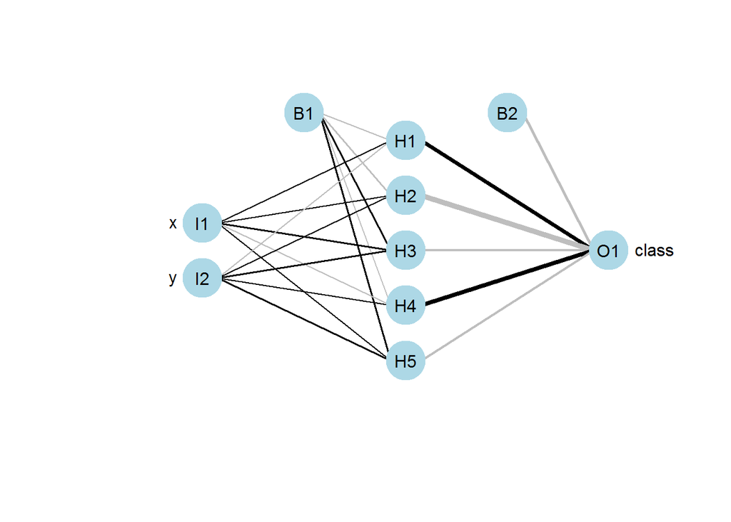

```r
plot(model)
```

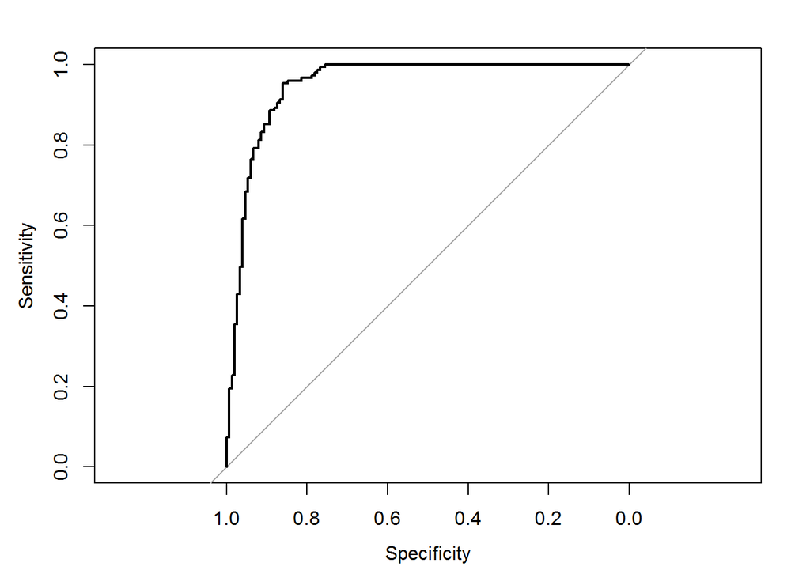

```
##
## Call:
## roc.default(response = mydata$class[-train], predictor = pihat)
##
## Data: pihat in 151 controls (mydata$class[-train] A) < 149 cases (mydata$class[-train] B).
## Area under the curve: 0.9502
```

```r
plot(roc(response=mydata$class[-train],predictor=pihat))
```

## GRADIENT DESCENT FOR MULTIPLE REGRESSION MODE

Creating some data

```r
set.seed(827)
x1=runif(100,0,20)
x2=rnorm(100,10,2)
X=cbind(rep(1,100),x1,x2)
y=100+5*x1+10*x2+10*rnorm(100)

#fitting a model
regmodel=lm(y~x1+x2)
summary(regmodel)
```

```
##
## Call:
## lm(formula = y ~ x1 + x2)
##
## Residuals:
##      Min       1Q   Median       3Q      Max
## -23.1211  -6.3682  -0.2909   6.2511  24.4870
##
## Coefficients:
##             Estimate Std. Error t value Pr(>|t|)
## (Intercept) 111.4399     5.3272   20.92   <2e-16 ***
## x1            4.7226     0.1665   28.36   <2e-16 ***
## x2            9.2248     0.4816   19.15   <2e-16 ***
## ---
## Signif. codes:  0 '***' 0.001 '**' 0.01 '*' 0.05 '.' 0.1 ' ' 1
##
## Residual standard error: 9.691 on 97 degrees of freedom
## Multiple R-squared:  0.9148, Adjusted R-squared:  0.913
## F-statistic: 520.6 on 2 and 97 DF,  p-value: < 2.2e-16
```

```r
what=coef(regmodel)
```

gradient function

```r
gradientfct=function(w){
  return(-t(X)%*%y+t(X)%*%X%*%w)
}

errorfct=function(w){
  e=y-X%*%w
  return(t(e)%*%e)
}

gradientfct(what)
```

```
##            [,1]
##    0.000000e+00
## x1 1.164153e-10
## x2 1.455192e-10
```

```r
errorfct(what)
```

```
##          [,1]
## [1,] 9110.314
```

gradientdescent function et0=initial learning rate maxit=maximum number of iterations abstol=absolute tolerance for norm of the gradient. If the norm of the gradient falls below abstol, the algorithm terminates.

```r
gradientdescent=function(gradientfct,errorfct,parameter0,eta0=0.1,maxit=100,abstol=10^-4){
  parameter=parameter0
  eta=eta0
  olderror=errorfct(parameter)
  for(i in 1:maxit){
    parameter=parameter-eta*gradientfct(parameter)
    if(sum(gradientfct(parameter)^2)<abstol){
      print(paste("Converged in",i,"iterations."))
      return(list(parameter=parameter,error=newerror,eta=eta))
    }
    newerror=errorfct(parameter)
    if(olderror>newerror){eta=1.1*eta}else{eta=0.5*eta}
    olderror=newerror
  }
  print(paste("Did not converge in",maxit,"iterations."))
  return(list(parameter=parameter,error=newerror,eta=eta))

}

what
```

```
## (Intercept)          x1          x2
##  111.439906    4.722597    9.224790
```

```r
gradientdescent(gradientfct,errorfct,parameter0=c(1,1,1),eta0=10^-5,maxit=100000)
```

```
## [1] "Converged in 30556 iterations."
```

```
## $parameter
##          [,1]
##    111.436880
## x1   4.722639
## x2   9.225044
##
## $error
##          [,1]
## [1,] 9110.314
##
## $eta
## [1] 7.436697e-05
```

A COMPLICATED DATA SET

[figure not shown]

```r
set.seed(5364)
n=100000
x=runif(n,0,50)
y=runif(n,0,50)
class=rep("A",n)
index1=(x<10)&(y>5/2*x)&(y<50-5/2*x)
index2=(y<10*sin(pi/50*x))
index3=(y>40)&(x>125-5/2*y)&(x<5/2*(y-40)+25)
index4=(x>15)&(x<35)&(y>15)&(y<35)
index5=((x-40)^2+(y-40)^2<81)
class[index1|index2|index3|index4|index5]="B"
class=as.factor(class)
mydata=data.frame(x,y,class)
plot(y~x,col=class,data=mydata)
```

trainsample function

```r
trainsample=function(dataset,trainprop){
  return(sample(nrow(dataset),
                round(nrow(dataset)*trainprop,0)))
}


train=trainsample(mydata,.7)


#Neural network with one hidden layer.
library(nnet)
model=nnet(class~.,data=mydata[train,],size=30)
predclass=predict(model,newdata=mydata[-train,],type="class")
confmatrix(mydata$class[-train],predclass)
```

```
## $matrix
##    predy
## y       A     B
##   A 10495  2252
##   B  1686 15567
##
## $accuracy
## [1] 0.8687333
##
## $error
## [1] 0.1312667
```

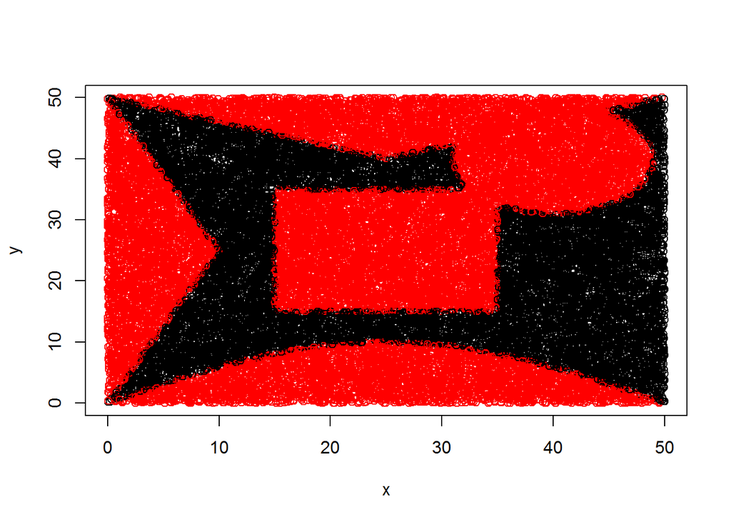

```r
#plot of test data
plot(y~x,data=mydata[-train,],col=class)
```

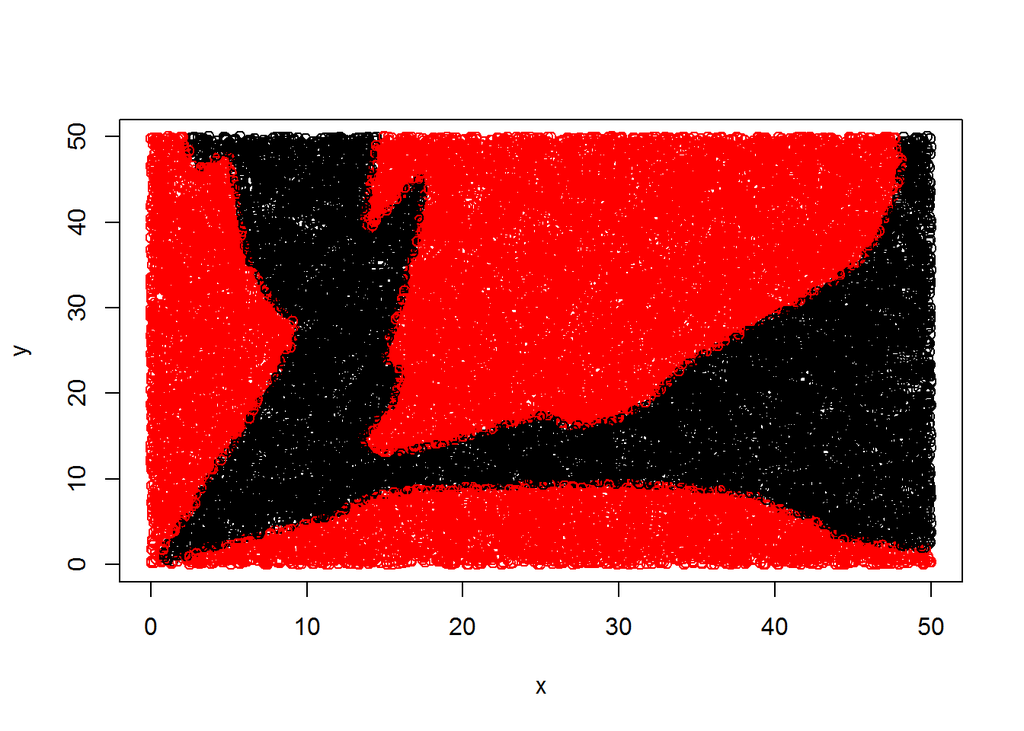

```r
#plot of model predictions
plot(y~x,data=mydata[-train,],col=as.factor(predclass))
```

CHANGING MAXIT TO LET GRADIENT DESCENT CONVERGE

This took about 2 minutes on my machine.

```r
model=nnet(class~.,data=mydata[train,],size=30,maxit=1000)
predclass=predict(model,newdata=mydata[-train,],type="class")
confmatrix(mydata$class[-train],predclass)
```

```
## $matrix
##    predy
## y       A     B
##   A 12532   215
##   B   180 17073
##
## $accuracy
## [1] 0.9868333
##
## $error
## [1] 0.01316667
```

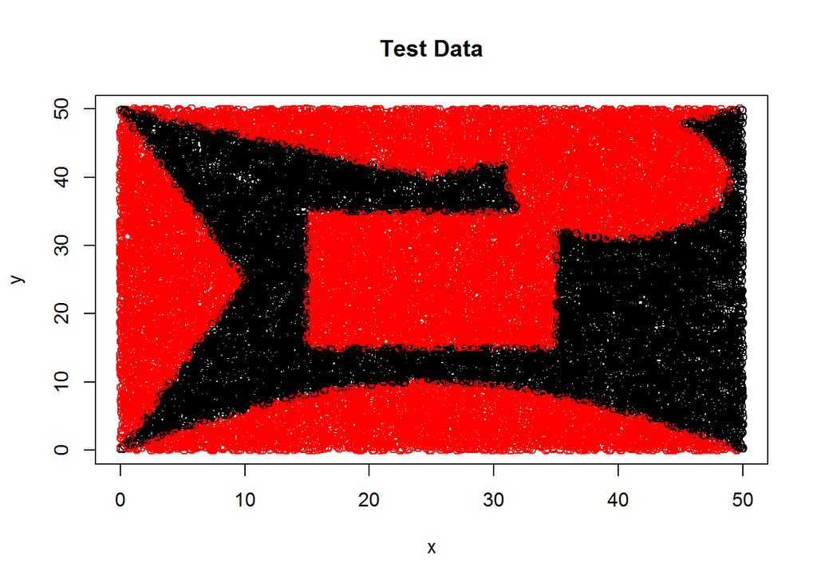

```r
#plot of test data
plot(y~x,data=mydata[-train,],col=class,main="Test Data")
```

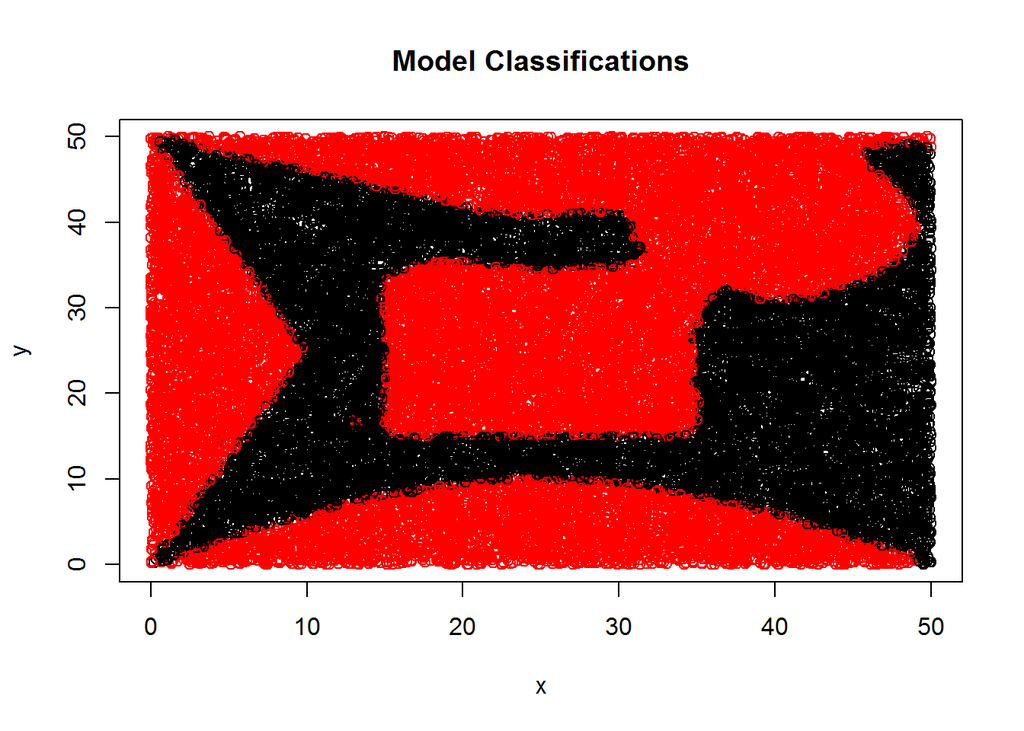

```r
#plot of model predictions
plot(y~x,data=mydata[-train,],col=as.factor(predclass),main="Model Classifications")
```

MULTILAYER PERCEPTRONS (NEURAL NETWORKS)

mlp with RSNNS Package

```r
library(RSNNS)
```

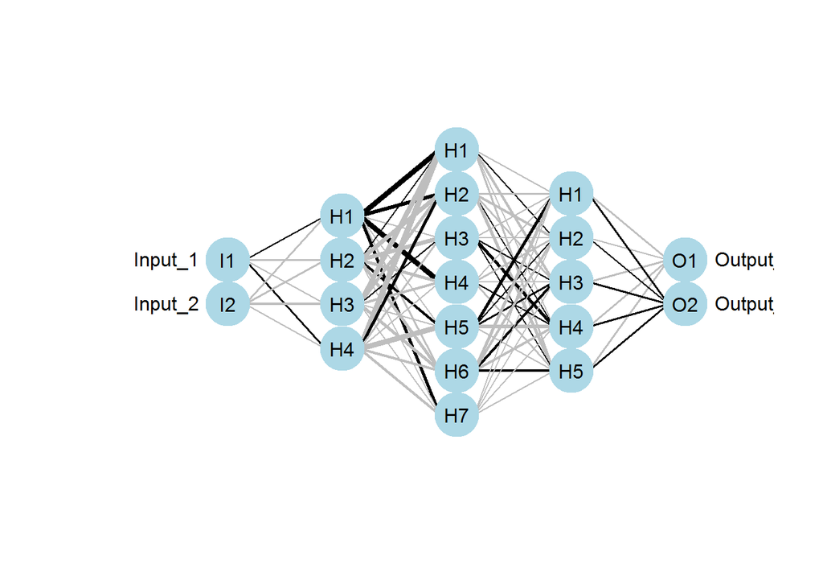

```r
mydataValues <- mydata[,1:2]
mydataTargets <- decodeClassLabels(mydata[,3])

MyData <- splitForTrainingAndTest(mydataValues, mydataTargets, ratio=0.3)
MyData <- normTrainingAndTestSet(MyData)

mlpmodel <- mlp(MyData$inputsTrain, MyData$targetsTrain, size=c(4,7,5), learnFuncParams=c(0.1),
                maxit=50, inputsTest=MyData$inputsTest, targetsTest=MyData$targetsTest)
plot.nnet(mlpmodel)
```

```r
head(mlpmodel$fittedTestValues)
```

```
##            [,1]        [,2]
## [1,] 0.08558255 0.914417624
## [2,] 0.01132405 0.988676012
## [3,] 0.01059657 0.989403486
## [4,] 0.99213058 0.007869373
## [5,] 0.98704362 0.012956318
## [6,] 0.07429752 0.925702631
```

```r
head(MyData$targetsTest)
```

```
##      A B
## [1,] 0 1
## [2,] 0 1
## [3,] 0 1
## [4,] 1 0
## [5,] 1 0
## [6,] 0 1
```

```r
predclass=(mlpmodel$fittedTestValues[,1]>=0.5)*1
confmatrix(MyData$targetsTest[,1],predclass)
```

```
## $matrix
##    predy
## y       0     1
##   0 15485  1875
##   1  1500 11140
##
## $accuracy
## [1] 0.8875
##
## $error
## [1] 0.1125
```

## ENSEMBLE METHODS

Load germancredit and select training sample

```r
library(caret)
germancredit = read.csv(url("http://faculty.tarleton.edu/crawford/documents/Math5364/germancredit.csv"))
germancredit$Default=as.factor(germancredit$Default)
set.seed(5364)

train=trainsample(germancredit,.7)
```

Decision Tree for germancredit

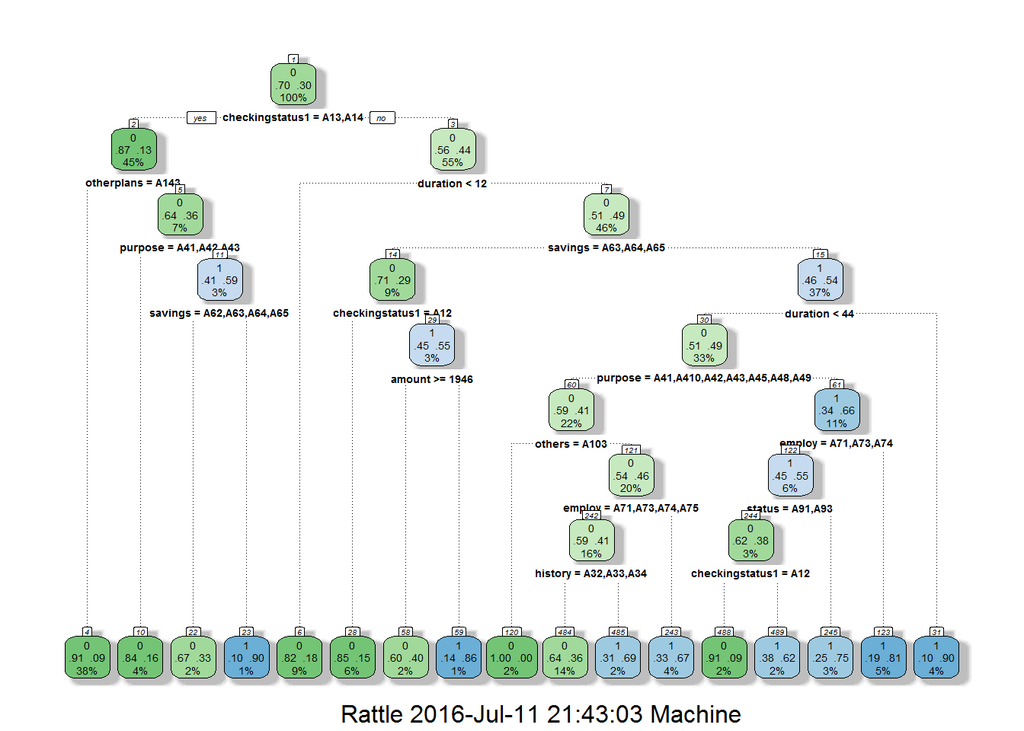

```r
library(rpart)
library(rattle)
mytree=rpart(Default~.,data=germancredit[train,])
fancyRpartPlot(mytree)
```

```r
predDefault=predict(mytree,newdata=germancredit[-train,],type="class")
confmatrix(germancredit$Default[-train],predDefault)
```

```
## $matrix
##    predy
## y     0   1
##   0 178  34
##   1  52  36
##
## $accuracy
## [1] 0.7133333
##
## $error
## [1] 0.2866667
```

```r
#adabag package
library(adabag)
#Bagging
baggingmodel=bagging(Default~.,data=germancredit[train,])
bagpred=predict(baggingmodel,newdata=germancredit[-train,],type="class")
bagpred
```

```
## $formula
## Default ~ .
##
## $votes
##        [,1] [,2]
##   [1,]   36   64
##   [2,]   99    1
##   [3,]   92    8
##   [4,]  100    0
##   [5,]   35   65
##   [6,]   39   61
##   [7,]  100    0
##   [8,]   35   65
##   [9,]   82   18
##  [10,]  100    0
```

[output cut: 622 more lines]

```r
#Random Forest package
library(randomForest)
forestmodel=randomForest(Default~.,data=germancredit[train,])
forestpred=predict(forestmodel,newdata=germancredit[-train,])
confmatrix(germancredit$Default[-train],forestpred)
```

```
## $matrix
##    predy
## y     0   1
##   0 194  18
##   1  52  36
##
## $accuracy
## [1] 0.7666667
##
## $error
## [1] 0.2333333
```

```r
#Boosting (Also from adabag package)
boostingmodel=boosting(Default~.,data=germancredit[train,])
boostpred=predict(boostingmodel,newdata=germancredit[-train,],type="class")
boostpred
```

```
## $formula
## Default ~ .
##
## $votes
##            [,1]      [,2]
##   [1,] 23.19722 25.307396
##   [2,] 32.31781 16.186810
##   [3,] 28.22116 20.283454
##   [4,] 31.67919 16.825429
##   [5,] 24.67476 23.829862
##   [6,] 18.02672 30.477897
##   [7,] 37.07277 11.431852
##   [8,] 18.12491 30.379706
##   [9,] 33.67059 14.834023
##  [10,] 36.78760 11.717014
```

[output cut: 622 more lines]

### THE MULTICLASS PROBLEM

ONE AGAINST ONE METHOD

training data for iris

```r
set.seed(5364)
train=trainsample(iris,.7)

#svm for iris
model=svm(Species~.,data=iris[train,])
predSpecies=predict(model,
                    newdata=iris[-train,],
                    type="class")
confmatrix(iris$Species[-train],predSpecies)
```

```
## $matrix
##             predy
## y            setosa versicolor virginica
##   setosa         19          0         0
##   versicolor      0         11         1
##   virginica       0          1        13
##
## $accuracy
## [1] 0.9555556
##
## $error
## [1] 0.04444444
```

one-against-one Method

```r
traindata=iris[train,]

#setosa/versicolor model
set.vers.train=traindata[(traindata$Species=="setosa")|
                           (traindata$Species=="versicolor"),]
set.vers.model=svm(Species~.,data=set.vers.train)
set.vers.pred=predict(set.vers.model,
                      newdata=iris[-train,],
                      type="class")


#setosa/virginica model
set.virg.train=traindata[(traindata$Species=="setosa")|
                           (traindata$Species=="virginica"),]
set.virg.model=svm(Species~.,data=set.virg.train)
set.virg.pred=predict(set.virg.model,
                      newdata=iris[-train,],
                      type="class")

#versicolor/virginica model
vers.virg.train=traindata[(traindata$Species=="versicolor")|
                            (traindata$Species=="virginica"),]
vers.virg.model=svm(Species~.,data=vers.virg.train)
vers.virg.pred=predict(vers.virg.model,
                       newdata=iris[-train,],
                       type="class")

#Tallying the votes
set.votes=(set.virg.pred=="setosa")+
  (set.vers.pred=="setosa")+
  (vers.virg.pred=="setosa")

vers.votes=(set.virg.pred=="versicolor")+
  (set.vers.pred=="versicolor")+
  (vers.virg.pred=="versicolor")

virg.votes=(set.virg.pred=="virginica")+
  (set.vers.pred=="virginica")+
  (vers.virg.pred=="virginica")

votes=cbind(set.votes,vers.votes,virg.votes)
apply(votes,1,which.max)
```

```
##  [1] 1 1 1 1 1 1 1 1 1 1 1 1 1 1 1 1 1 1 1 2 2 2 2 2 2 2 3 2 2 2 2 3 3 3 3
## [36] 3 3 3 3 3 3 3 3 3 3
```

```r
one.against.one.pred=c("setosa",
                       "versicolor",
                       "virginica")[apply(votes,
                                          1,
                                          which.max)]

table(predSpecies,one.against.one.pred)
```

```
##             one.against.one.pred
## predSpecies  setosa versicolor virginica
##   setosa         19          0         0
##   versicolor      0         11         1
##   virginica       0          0        14
```

```r
predSpecies==one.against.one.pred
```

```
##  [1]  TRUE  TRUE  TRUE  TRUE  TRUE  TRUE  TRUE  TRUE  TRUE  TRUE  TRUE
## [12]  TRUE  TRUE  TRUE  TRUE  TRUE  TRUE  TRUE  TRUE  TRUE  TRUE  TRUE
## [23]  TRUE  TRUE  TRUE  TRUE  TRUE  TRUE  TRUE  TRUE  TRUE  TRUE  TRUE
## [34]  TRUE  TRUE  TRUE  TRUE  TRUE  TRUE  TRUE  TRUE FALSE  TRUE  TRUE
## [45]  TRUE
```

ONE AGAINST REST METHOD

releveling Species variable

```r
levels(iris$Species)
```

```
## [1] "setosa"     "versicolor" "virginica"
```

```r
levels(iris$Species)=c(levels(iris$Species),"other")

traindata=iris[train,]


#setosa against the rest model
set.train=traindata
set.train$Species[(set.train$Species!="setosa")]="other"

table(traindata$Species)
```

```
##
##     setosa versicolor  virginica      other
##         31         38         36          0
```

```r
table(set.train$Species)
```

```
##
##     setosa versicolor  virginica      other
##         31          0          0         74
```

```r
set.model=svm(Species~.,data=set.train)
set.pred=predict(set.model,
                 newdata=iris[-train,],
                 type="class")

table(set.pred,iris$Species[-train])
```

```
##
## set.pred     setosa versicolor virginica other
##   setosa         19          0         0     0
##   versicolor      0          0         0     0
##   virginica       0          0         0     0
##   other           0         12        14     0
```

```r
#versicolor against the rest model
vers.train=traindata
vers.train$Species[(vers.train$Species!="versicolor")]="other"

table(traindata$Species)
```

```
##
##     setosa versicolor  virginica      other
##         31         38         36          0
```

```r
table(vers.train$Species)
```

```
##
##     setosa versicolor  virginica      other
##          0         38          0         67
```

```r
vers.model=svm(Species~.,data=vers.train)
vers.pred=predict(vers.model,
                  newdata=iris[-train,],
                  type="class")

table(vers.pred,iris$Species[-train])
```

```
##
## vers.pred    setosa versicolor virginica other
##   setosa          0          0         0     0
##   versicolor      0         11         1     0
##   virginica       0          0         0     0
##   other          19          1        13     0
```

```r
#virginica against the rest model
virg.train=traindata
virg.train$Species[(virg.train$Species!="virginica")]="other"

table(traindata$Species)
```

```
##
##     setosa versicolor  virginica      other
##         31         38         36          0
```

```r
table(virg.train$Species)
```

```
##
##     setosa versicolor  virginica      other
##          0          0         36         69
```

```r
virg.model=svm(Species~.,data=virg.train)
virg.pred=predict(virg.model,
                  newdata=iris[-train,],
                  type="class")

table(virg.pred,iris$Species[-train])
```

```
##
## virg.pred    setosa versicolor virginica other
##   setosa          0          0         0     0
##   versicolor      0          0         0     0
##   virginica       0          1        13     0
##   other          19         11         1     0
```

```r
#Tallying votes
set.votes2=(set.pred=="setosa")+
  (vers.pred=="other")+
  (virg.pred=="other")

vers.votes2=(set.pred=="other")+
  (vers.pred=="versicolor")+
  (virg.pred=="other")

virg.votes2=(set.pred=="other")+
  (vers.pred=="other")+
  (virg.pred=="virginica")


votes2=cbind(set.votes2,vers.votes2,virg.votes2)

one.against.rest.pred=c("setosa",
                        "versicolor",
                        "virginica")[apply(votes2,
                                           1,
                                           which.max)]

table(predSpecies,one.against.rest.pred)
```

```
##             one.against.rest.pred
## predSpecies  setosa versicolor virginica
##   setosa         19          0         0
##   versicolor      0         12         0
##   virginica       0          0        14
```

Three accuracies

```r
data(iris)
levels(iris$Species)
```

```
## [1] "setosa"     "versicolor" "virginica"
```

```r
#svm package predictions
confmatrix(iris$Species[-train],
           predSpecies)
```

```
## $matrix
##             predy
## y            setosa versicolor virginica
##   setosa         19          0         0
##   versicolor      0         11         1
##   virginica       0          1        13
##
## $accuracy
## [1] 0.9555556
##
## $error
## [1] 0.04444444
```

```r
#one-against-one
confmatrix(iris$Species[-train],
           one.against.one.pred)
```

```
## $matrix
##             predy
## y            setosa versicolor virginica
##   setosa         19          0         0
##   versicolor      0         11         1
##   virginica       0          0        14
##
## $accuracy
## [1] 0.9777778
##
## $error
## [1] 0.02222222
```

```r
#one-against-rest
confmatrix(iris$Species[-train],
           one.against.rest.pred)
```

```
## $matrix
##             predy
## y            setosa versicolor virginica
##   setosa         19          0         0
##   versicolor      0         11         1
##   virginica       0          1        13
##
## $accuracy
## [1] 0.9555556
##
## $error
## [1] 0.04444444
```

which.max

```r
x=c(1,1,9,1,1,1,9,1)
which.max(x)
```

```
## [1] 3
```

```r
(1:length(x))[x==(max(x))]
```

```
## [1] 3 7
```

```r
sample(((1:length(x))[x==(max(x))]),1)
```

```
## [1] 3
```

```r
x=c(1,1,1,1,1,1,9,1)
sample(((1:length(x))[x==(max(x))]),1)
```

```
## [1] 5
```

```r
#randomizing which.max
#(can be used for breaking ties in voting)

rand.which.max=function(x){
  index=((1:length(x))[x==(max(x))])
  return(sample(c(index,index),1))
}

rand.which.max(x)
```

```
## [1] 7
```

PROGRAMMING ONE-AGAINST-REST

Levels of Species and k

```r
data(iris)
iris.levels=levels(iris$Species)
k=length(iris.levels)

#Adding "other" back to iris data
levels(iris$Species)=c(levels(iris$Species),"other")
traindata=iris[train,]

#Creating lists to store models and predictions
model.list=vector(length=k,mode="list")
pred.list=vector(length=k,mode="list")

#Creating models and predictions
for(i in 1:k){
  i.train=traindata
  i.train$Species[(i.train$Species!=iris.levels[i])]="other"
  i.model=svm(Species~.,data=i.train)
  i.pred=predict(i.model,
                 newdata=iris[-train,],
                 type="class")
  model.list[[i]]=i.model
  pred.list[[i]]=i.pred
}

#Checking model list
model.list
```

```
## [[1]]
##
## Call:
## svm(formula = Species ~ ., data = i.train)
##
##
## Parameters:
##    SVM-Type:  C-classification
##  SVM-Kernel:  radial
##        cost:  1
##       gamma:  0.25
##
## Number of Support Vectors:  14
##
##
## [[2]]
##
## Call:
## svm(formula = Species ~ ., data = i.train)
##
##
## Parameters:
##    SVM-Type:  C-classification
##  SVM-Kernel:  radial
##        cost:  1
##       gamma:  0.25
##
## Number of Support Vectors:  35
##
##
## [[3]]
##
## Call:
## svm(formula = Species ~ ., data = i.train)
##
##
## Parameters:
##    SVM-Type:  C-classification
##  SVM-Kernel:  radial
##        cost:  1
##       gamma:  0.25
##
## Number of Support Vectors:  37
```

```r
set.model$SV
```

```
##     Sepal.Length Sepal.Width Petal.Length Petal.Width
## 51     1.3881139   0.3428528    0.5039782  0.21099516
## 61    -1.0635591  -2.3403428   -0.2023761 -0.31965135
## 132    2.4913667   1.6844506    1.5046468  1.00696494
## 96    -0.2054735  -0.1043465    0.2096639 -0.05432810
## 65    -0.3280572  -0.3279461   -0.1435133  0.07833353
## 119    2.2461994  -0.9987450    1.7989611  1.40494982
## 149    0.4074447   0.7900520    0.9160182  1.40494982
## 99    -0.9409754  -1.2223447   -0.4966904 -0.18698972
## 26    -1.0635591  -0.1043465   -1.3207705 -1.38094439
## 44    -1.0635591   1.0136517   -1.3207705 -0.85029787
## 46    -1.3087264  -0.1043465   -1.4384962 -1.24828276
## 16    -0.2054735   3.0260483   -1.3796333 -1.11562113
## 33    -0.8183918   2.3552494   -1.3796333 -1.51360601
## 14    -1.9216446  -0.1043465   -1.6150848 -1.51360601
```

```r
(model.list[[1]])$SV
```

```
##     Sepal.Length Sepal.Width Petal.Length Petal.Width
## 51     1.3881139   0.3428528    0.5039782  0.21099516
## 61    -1.0635591  -2.3403428   -0.2023761 -0.31965135
## 132    2.4913667   1.6844506    1.5046468  1.00696494
## 96    -0.2054735  -0.1043465    0.2096639 -0.05432810
## 65    -0.3280572  -0.3279461   -0.1435133  0.07833353
## 119    2.2461994  -0.9987450    1.7989611  1.40494982
## 149    0.4074447   0.7900520    0.9160182  1.40494982
## 99    -0.9409754  -1.2223447   -0.4966904 -0.18698972
## 26    -1.0635591  -0.1043465   -1.3207705 -1.38094439
## 44    -1.0635591   1.0136517   -1.3207705 -0.85029787
## 46    -1.3087264  -0.1043465   -1.4384962 -1.24828276
## 16    -0.2054735   3.0260483   -1.3796333 -1.11562113
## 33    -0.8183918   2.3552494   -1.3796333 -1.51360601
## 14    -1.9216446  -0.1043465   -1.6150848 -1.51360601
```

```r
#Checking pred list
pred.list[[1]]
```

```
##      4      6      8      9     11     15     17     19     21     24
## setosa setosa setosa setosa setosa setosa setosa setosa setosa setosa
##     27     30     31     32     35     36     42     48     50     55
## setosa setosa setosa setosa setosa setosa setosa setosa setosa  other
##     58     60     62     64     69     81     84     86     89     92
##  other  other  other  other  other  other  other  other  other  other
##     95    101    103    105    106    108    111    123    126    130
##  other  other  other  other  other  other  other  other  other  other
##    133    134    137    139    147
##  other  other  other  other  other
## Levels: setosa versicolor virginica other
```

```r
pred.list[[2]]
```

```
##          4          6          8          9         11         15
##      other      other      other      other      other      other
##         17         19         21         24         27         30
##      other      other      other      other      other      other
##         31         32         35         36         42         48
##      other      other      other      other      other      other
##         50         55         58         60         62         64
##      other versicolor versicolor versicolor versicolor versicolor
##         69         81         84         86         89         92
## versicolor versicolor      other versicolor versicolor versicolor
##         95        101        103        105        106        108
## versicolor      other      other      other      other      other
##        111        123        126        130        133        134
##      other      other      other      other      other versicolor
##        137        139        147
##      other      other      other
## Levels: setosa versicolor virginica other
```

```r
pred.list[[3]]
```

```
##         4         6         8         9        11        15        17
##     other     other     other     other     other     other     other
##        19        21        24        27        30        31        32
##     other     other     other     other     other     other     other
##        35        36        42        48        50        55        58
##     other     other     other     other     other     other     other
##        60        62        64        69        81        84        86
##     other     other     other     other     other virginica     other
##        89        92        95       101       103       105       106
##     other     other     other virginica virginica virginica virginica
##       108       111       123       126       130       133       134
## virginica virginica virginica virginica virginica virginica     other
##       137       139       147
## virginica virginica virginica
## Levels: setosa versicolor virginica other
```

```r
pred.list[[1]]==set.pred
```

```
##  [1] TRUE TRUE TRUE TRUE TRUE TRUE TRUE TRUE TRUE TRUE TRUE TRUE TRUE TRUE
## [15] TRUE TRUE TRUE TRUE TRUE TRUE TRUE TRUE TRUE TRUE TRUE TRUE TRUE TRUE
## [29] TRUE TRUE TRUE TRUE TRUE TRUE TRUE TRUE TRUE TRUE TRUE TRUE TRUE TRUE
## [43] TRUE TRUE TRUE
```

```r
pred.list[[2]]==vers.pred
```

```
##  [1] TRUE TRUE TRUE TRUE TRUE TRUE TRUE TRUE TRUE TRUE TRUE TRUE TRUE TRUE
## [15] TRUE TRUE TRUE TRUE TRUE TRUE TRUE TRUE TRUE TRUE TRUE TRUE TRUE TRUE
## [29] TRUE TRUE TRUE TRUE TRUE TRUE TRUE TRUE TRUE TRUE TRUE TRUE TRUE TRUE
## [43] TRUE TRUE TRUE
```

```r
pred.list[[3]]==virg.pred
```

```
##  [1] TRUE TRUE TRUE TRUE TRUE TRUE TRUE TRUE TRUE TRUE TRUE TRUE TRUE TRUE
## [15] TRUE TRUE TRUE TRUE TRUE TRUE TRUE TRUE TRUE TRUE TRUE TRUE TRUE TRUE
## [29] TRUE TRUE TRUE TRUE TRUE TRUE TRUE TRUE TRUE TRUE TRUE TRUE TRUE TRUE
## [43] TRUE TRUE TRUE
```

```r
all(pred.list[[1]]==set.pred)
```

```
## [1] TRUE
```

```r
all(pred.list[[2]]==vers.pred)
```

```
## [1] TRUE
```

```r
all(pred.list[[3]]==virg.pred)
```

```
## [1] TRUE
```

```r
#Votes
vote.matrix=matrix(0,nrow=nrow(iris[-train,]),
                   ncol=k)
vote.matrix
```

```
##       [,1] [,2] [,3]
##  [1,]    0    0    0
##  [2,]    0    0    0
##  [3,]    0    0    0
##  [4,]    0    0    0
##  [5,]    0    0    0
##  [6,]    0    0    0
##  [7,]    0    0    0
##  [8,]    0    0    0
##  [9,]    0    0    0
## [10,]    0    0    0
## [11,]    0    0    0
## [12,]    0    0    0
## [13,]    0    0    0
## [14,]    0    0    0
```

[output cut: 31 more lines]

```r
dim(vote.matrix)
```

```
## [1] 45  3
```

```r
for(i in 1:k){
  vote.matrix[,i]=vote.matrix[,i]+
    (pred.list[[i]]==iris.levels[i])*1

  vote.matrix[,-i]=vote.matrix[,-i]+
    (pred.list[[i]]=="other")*1
}


#Checking vote matrix
vote.matrix==votes2
```

```
##       set.votes2 vers.votes2 virg.votes2
##  [1,]       TRUE        TRUE        TRUE
##  [2,]       TRUE        TRUE        TRUE
##  [3,]       TRUE        TRUE        TRUE
##  [4,]       TRUE        TRUE        TRUE
##  [5,]       TRUE        TRUE        TRUE
##  [6,]       TRUE        TRUE        TRUE
##  [7,]       TRUE        TRUE        TRUE
##  [8,]       TRUE        TRUE        TRUE
##  [9,]       TRUE        TRUE        TRUE
## [10,]       TRUE        TRUE        TRUE
## [11,]       TRUE        TRUE        TRUE
## [12,]       TRUE        TRUE        TRUE
## [13,]       TRUE        TRUE        TRUE
## [14,]       TRUE        TRUE        TRUE
```

[output cut: 31 more lines]

```r
all(vote.matrix==votes2)
```

```
## [1] TRUE
```

```r
#Creating one-against-rest predictions with rand.which.max
OAR.pred=iris.levels[apply(vote.matrix,
                           1,
                           rand.which.max)]


all(OAR.pred==one.against.rest.pred)
```

```
## [1] TRUE
```